# NMA for Binary data (2-arm trials)

Beth Ashlee

2020-06-19

## Introduction

This vignette provides a short example of a Bayesian NMA for Binary data. The model fit relies on the `gemtc` package, pre- and post-processing is done with `gemtcPlus`.

## Prepare the environment

```r
library(dplyr)
library(gemtc)
library(gemtcPlus)
library(ggmcmc)
```

## Load in the data

```r
data("binary_data", package = "gemtcPlus") # This should be binary
```

## Plan the model

```r
model_plan <- plan_binary(bth.model = "RE",
                          n.chain = 3,
                          n.iter = 6000,
                          thin = 1,
                          n.adapt = 1000,
                          link = "logit",
                          bth.prior =  mtc.hy.prior(type = "var",
                                                   distr = "dlnorm",-4.18, 1 / 1.41 ^ 2)
                          )
```

## Ready the data

```r
model_input <- nma_pre_proc(binary_data, plan = model_plan)
```

**Figure** Network plot

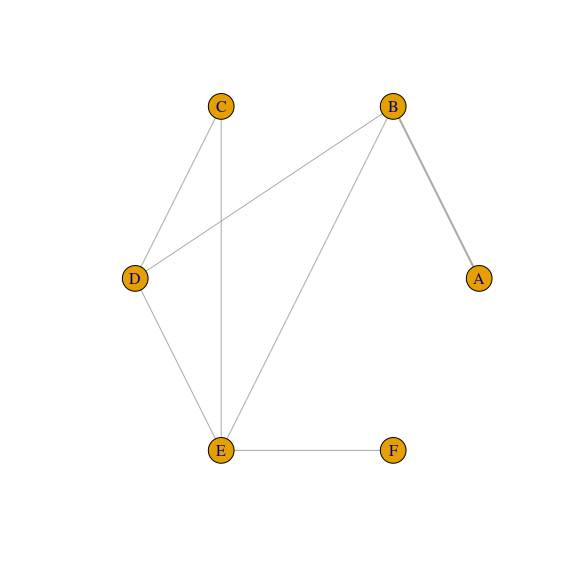

```r
plot(model_input$fitting_data)
```

## Fit the model

```r
model  <- nma_fit(model_input = model_input)
```

# Post processing

## Inspect convergence

The `ggmcmc` package provides ggplot2 versions of all major convergence plots and diagnostics.

**Figure** Traceplot

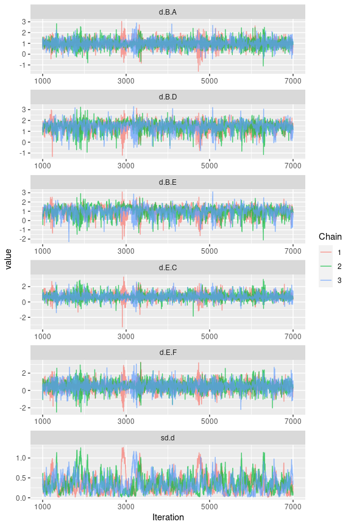

```r
ggs_traceplot(ggs(model$samples))
```

**Figure** Densityplot

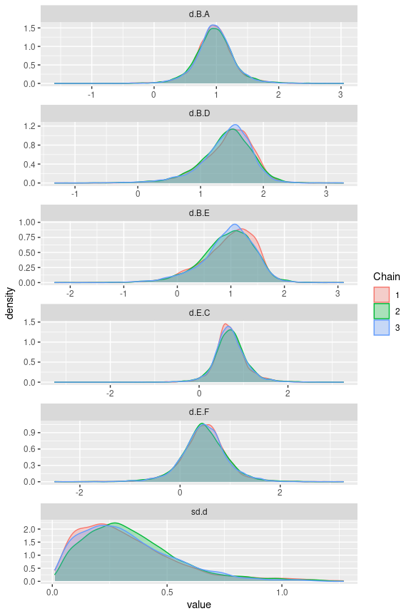

```r
ggs_density(ggs(model$samples))
```

Many more diagnostic plots are available, such as Brooks-Gelman-Rubin convergence diagnostic (Rhat), auto-correlation plot, or running means.

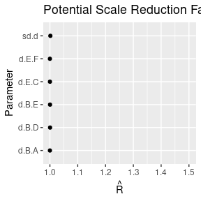

```r
ggs_Rhat(ggs(model$samples))
```

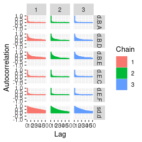

```r
ggs_autocorrelation(ggs(model$samples))
```

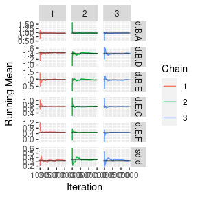

```r
ggs_running(ggs(model$samples))
```

# Produce outputs of interest

## Posterior summaries (log-scale)

The contrasts in this model are log-odds ratios.

Unfortunately, `gemtc` does not provide an estimate of the effective sample size (`n.eff`). Instead, a time-series SE is given. As a rule of thumb, the length of the MCMC is sufficient if the time-series SE is smaller than 2%(-5%) of the posterior SD.

```r
summary(model)
```

```
##
## Results on the Log Odds Ratio scale
##
## Iterations = 1001:7000
## Thinning interval = 1
## Number of chains = 3
## Sample size per chain = 6000
##
## 1. Empirical mean and standard deviation for each variable,
##    plus standard error of the mean:
##
##         Mean     SD Naive SE Time-series SE
## d.B.A 0.9716 0.3139 0.002339       0.003965
## d.B.D 1.4223 0.4111 0.003064       0.013025
## d.B.E 0.9557 0.4954 0.003692       0.019282
## d.E.C 0.7089 0.3619 0.002697       0.005497
## d.E.F 0.4833 0.4589 0.003420       0.006693
## sd.d  0.3327 0.2107 0.001570       0.012529
##
## 2. Quantiles for each variable:
##
##           2.5%    25%    50%    75% 97.5%
## d.B.A  0.34004 0.7957 0.9706 1.1443 1.625
## d.B.D  0.47000 1.2046 1.4733 1.6929 2.087
## d.B.E -0.17917 0.6791 1.0172 1.3013 1.745
## d.E.C  0.02757 0.5020 0.6907 0.8987 1.506
## d.E.F -0.46041 0.2272 0.4820 0.7417 1.414
## sd.d   0.04982 0.1779 0.2936 0.4423 0.873
##
## -- Model fit (residual deviance):
##
##     Dbar       pD      DIC
## 21.36866 15.90033 37.26899
##
## 16 data points, ratio 1.336, I^2 = 30%
```

To judge overall model fit, the residual deviance should be compared to the number of independent data points (which can be done via a small utility function in `gemtcPlus`).

```r
get_mtc_sum(model)
```

```
##     DIC   pD resDev dataPoints
## 1 37.27 15.9  21.37         16
```

## Odds ratio (OR) estimates

Assume new treatment is “A” and is to be compared vs all other treatments.

**Table** Odds ratios treatment A vs other treatments

```r
OR <- get_mtc_newVsAll(model, new.lab = "A", transform = "exp", digits = 2)
OR
```

```
##   Comparator  Med CIlo CIup
## 1          B 2.64 1.41 5.08
## 2          C 0.47 0.18 2.02
## 3          D 0.60 0.26 2.09
## 4          E 0.95 0.39 4.00
## 5          F 0.58 0.18 3.38
```

**Table** Probability A better than other treatments (better meaning larger OR)

```r
get_mtc_probBetter(model, new.lab = "A", smaller.is.better = FALSE, sort.by = "effect")
```

```
##   New Comparator probNewBetter
## 1   A          B         0.995
## 4   A          E         0.461
## 5   A          F         0.223
## 3   A          D         0.165
## 2   A          C         0.112
```

**Figure** Forest plot A vs other treatments

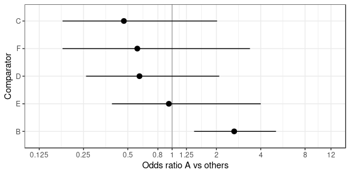

```r
plot_mtc_forest(x = OR,
                lab = "Odds ratio A vs others",
                breaks = c(0.125, 0.25, 0.5, 0.8, 1, 1.25, 2, 4, 8, 12),
                sort.by = "effect")
```

**Table** Cross-tabulation of ORs

```r
ctab <- round(exp(relative.effect.table(model)), 2)
pander::pandoc.table(as.data.frame(ctab), split.tables = Inf)
```

|  | A | B | C | D | E | F |
| --- | --- | --- | --- | --- | --- | --- |
| **A** | A | 0.38 (0.2, 0.71) | 2.14 (0.49, 5.57) | 1.66 (0.48, 3.84) | 1.05 (0.25, 2.58) | 1.72 (0.3, 5.67) |
| **B** | 2.64 (1.41, 5.08) | B | 5.64 (1.6, 12.07) | 4.36 (1.6, 8.06) | 2.77 (0.84, 5.73) | 4.53 (0.91, 13.17) |
| **C** | 0.47 (0.18, 2.02) | 0.18 (0.08, 0.63) | C | 0.78 (0.4, 1.64) | 0.5 (0.22, 0.97) | 0.82 (0.23, 2.46) |
| **D** | 0.6 (0.26, 2.09) | 0.23 (0.12, 0.63) | 1.29 (0.61, 2.48) | D | 0.64 (0.3, 1.15) | 1.04 (0.29, 2.96) |
| **E** | 0.95 (0.39, 4) | 0.36 (0.17, 1.2) | 2 (1.03, 4.51) | 1.56 (0.87, 3.38) | E | 1.62 (0.63, 4.11) |
| **F** | 0.58 (0.18, 3.38) | 0.22 (0.08, 1.1) | 1.23 (0.41, 4.37) | 0.96 (0.34, 3.45) | 0.62 (0.24, 1.58) | F |

## Treatment rankings

```r
rk  <- rank.probability(model, preferredDirection = 1)
mrk <- reshape2::melt(rk[,], varnames = c("Treatment", "Rank"), value.name = "Probability")

fig <- ggplot(data = mrk) +
  geom_line(aes(Rank, Probability, color = Treatment, linetype = Treatment), size = 1.5) +
  theme_bw()
```

**Figure** Rankogram

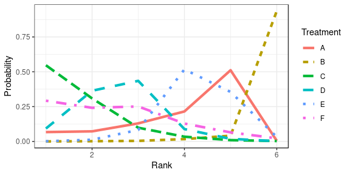

```r
plot(fig)
```

**Table** Rank probabilities

```r
colnames(rk) <- paste("Rank", 1:ncol(rk))
rk
```

```
## Rank probability; preferred direction = 1
##         Rank 1     Rank 2      Rank 3     Rank 4      Rank 5      Rank 6
## A 6.716667e-02 0.07233333 0.129722222 0.21522222 0.511166667 0.004388889
## B 5.555556e-05 0.00150000 0.003944444 0.01672222 0.041222222 0.936555556
## C 5.467222e-01 0.30888889 0.098277778 0.03388889 0.009277778 0.002944444
## D 9.244444e-02 0.36394444 0.434722222 0.08866667 0.018444444 0.001777778
## E 1.277778e-03 0.01200000 0.082388889 0.51711111 0.355055556 0.032166667
## F 2.923333e-01 0.24133333 0.250944444 0.12838889 0.064833333 0.022166667
```

# Node-splitting (inconsistency assessment)

```r
nsplit <- mtc.nodesplit(model$model$network)
summary(nsplit)
```

```
## Node-splitting analysis of inconsistency
## ========================================
##
##    comparison  p.value  CrI
## 1  d.B.D       0.074750
## 2  -> direct            1.9 (0.27, 3.4)
## 3  -> indirect          -0.43 (-2.8, 1.8)
## 4  -> network           1.2 (-0.68, 2.8)
## 5  d.B.E       0.079450
## 6  -> direct            -0.58 (-2.5, 1.3)
## 7  -> indirect          1.7 (-0.35, 3.8)
## 8  -> network           0.57 (-1.4, 2.2)
## 9  d.C.D       0.961550
## 10 -> direct            -0.20 (-2.6, 2.2)
## 11 -> indirect          -0.13 (-3.3, 3.2)
## 12 -> network           -0.20 (-1.9, 1.6)
## 13 d.C.E       0.959775
## 14 -> direct            -0.76 (-3.2, 1.7)
## 15 -> indirect          -0.85 (-4.1, 2.3)
## 16 -> network           -0.78 (-2.5, 0.89)
## 17 d.D.E       0.223575
## 18 -> direct            0.099 (-2.0, 2.2)
## 19 -> indirect          -1.3 (-3.6, 0.66)
## 20 -> network           -0.59 (-2.2, 0.89)
```

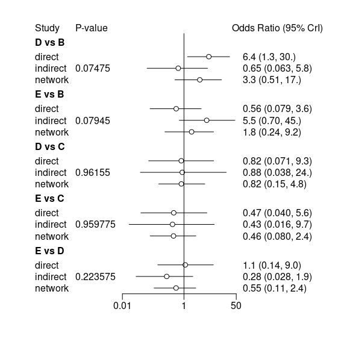

```r
plot(summary(nsplit))
```

# Forest plot

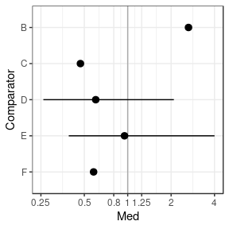

```r
HR_i    <- get_mtc_newVsAll(model, new.lab = "A", transform = "exp", digits = 2)
plot_mtc_forest(HR_i)
```

# Extract model code (e.g. for Appendix)

```r
cat(model$code)
```

[output not shown]

[output not shown]